# Statistical power of piecewise-regression analyses in single-case experiments addressing behaviour problems

Jürgen Wilbert

2022-04-11

# Figure single-case parameters

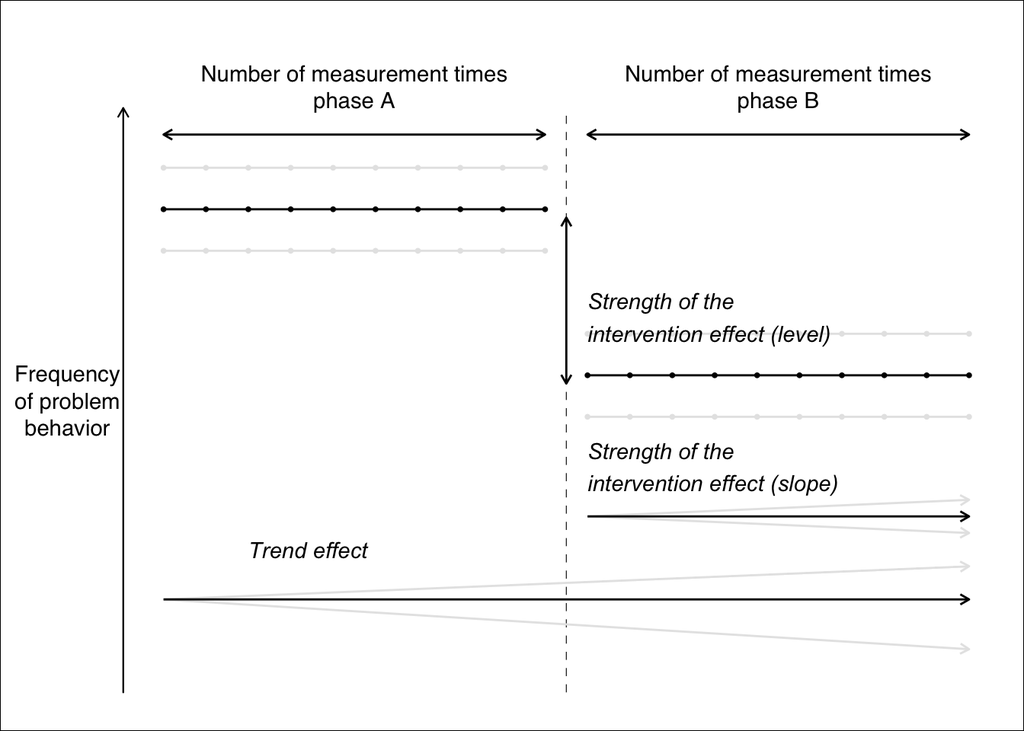

# Example single-cases

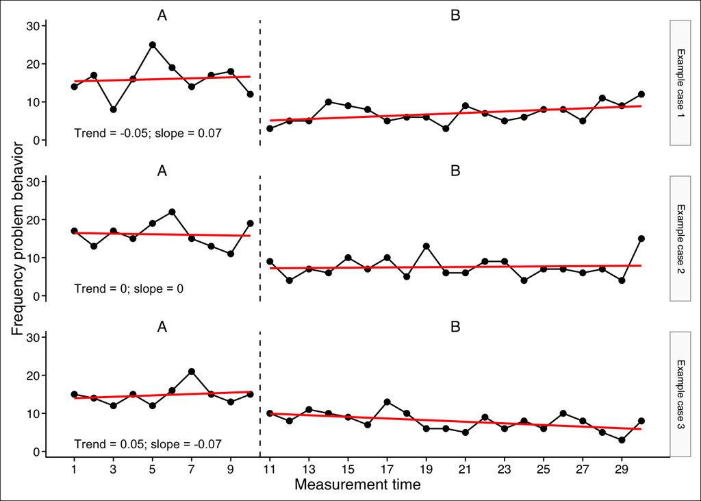

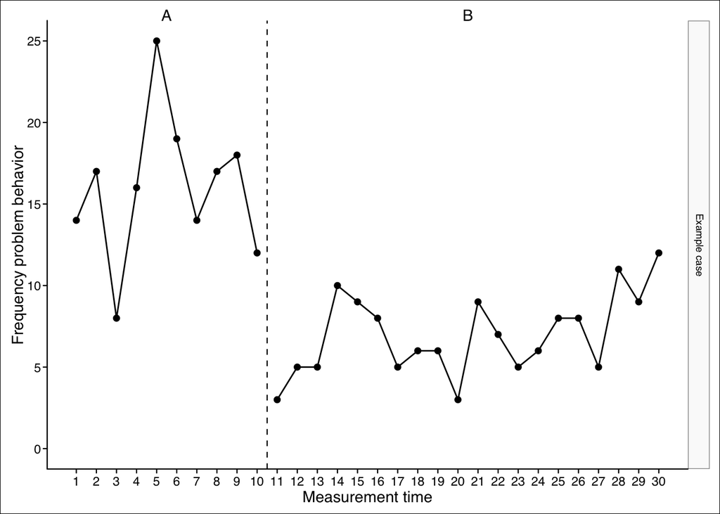

Piecewise-regression model predicting variable ‘values’

| Parameter | B | CI(95%) 2.5% | CI(95%) 97.5% | SE | t | p | Odds Ratio | CI(95%) 2.5% | CI(95%) 97.5% | Yule’s Q | CI(95%) 2.5% | CI(95%) 97.5% |
| --- | --- | --- | --- | --- | --- | --- | --- | --- | --- | --- | --- | --- |
| Intercept | 2.73 | 2.38 | 3.05 | 0.17 | 15.81 | 0.00 | 15.28 | 10.78 | 21.21 | 0.88 | 0.83 | 0.91 |
| Trend mt | 0.01 | -0.05 | 0.06 | 0.03 | 0.30 | 0.76 | 1.01 | 0.96 | 1.06 | 0.00 | -0.02 | 0.03 |
| Level phase B | -1.18 | -1.65 | -0.71 | 0.24 | -4.93 | 0.00 | 0.31 | 0.19 | 0.49 | -0.53 | -0.68 | -0.34 |
| Slope phase B | 0.02 | -0.04 | 0.08 | 0.03 | 0.65 | 0.52 | 1.02 | 0.96 | 1.08 | 0.01 | -0.02 | 0.04 |

Note:  
X²(3) = 54.38; p <.001; AIC = 154

Piecewise-regression model predicting variable ‘values’

| Parameter | B | CI(95%) 2.5% | CI(95%) 97.5% | SE | t | p | Odds Ratio | CI(95%) 2.5% | CI(95%) 97.5% | Yule’s Q | CI(95%) 2.5% | CI(95%) 97.5% |
| --- | --- | --- | --- | --- | --- | --- | --- | --- | --- | --- | --- | --- |
| Intercept | 2.81 | 2.46 | 3.13 | 0.17 | 16.57 | 0.00 | 16.54 | 11.74 | 22.82 | 0.89 | 0.84 | 0.92 |
| Trend mt | 0.00 | -0.06 | 0.05 | 0.03 | -0.18 | 0.86 | 1.00 | 0.94 | 1.05 | 0.00 | -0.03 | 0.02 |
| Level phase B | -0.78 | -1.23 | -0.34 | 0.23 | -3.48 | 0.00 | 0.46 | 0.29 | 0.71 | -0.37 | -0.55 | -0.17 |
| Slope phase B | 0.01 | -0.05 | 0.07 | 0.03 | 0.31 | 0.76 | 1.01 | 0.95 | 1.07 | 0.00 | -0.03 | 0.04 |

Note:  
X²(3) = 44.14; p <.001; AIC = 156

Piecewise-regression model predicting variable ‘values’

| Parameter | B | CI(95%) 2.5% | CI(95%) 97.5% | SE | t | p | Odds Ratio | CI(95%) 2.5% | CI(95%) 97.5% | Yule’s Q | CI(95%) 2.5% | CI(95%) 97.5% |
| --- | --- | --- | --- | --- | --- | --- | --- | --- | --- | --- | --- | --- |
| Intercept | 2.63 | 2.26 | 2.97 | 0.18 | 14.57 | 0.00 | 13.82 | 9.60 | 19.46 | 0.87 | 0.81 | 0.90 |
| Trend mt | 0.01 | -0.04 | 0.07 | 0.03 | 0.43 | 0.67 | 1.01 | 0.96 | 1.07 | 0.01 | -0.02 | 0.03 |
| Level phase B | -0.41 | -0.83 | 0.02 | 0.22 | -1.89 | 0.06 | 0.66 | 0.43 | 1.01 | -0.20 | -0.39 | 0.01 |
| Slope phase B | -0.04 | -0.10 | 0.02 | 0.03 | -1.24 | 0.22 | 0.96 | 0.90 | 1.02 | -0.02 | -0.05 | 0.01 |

Note:  
X²(3) = 33.47; p <.001; AIC = 145

# Length of A and B phase and intervention effectiveness

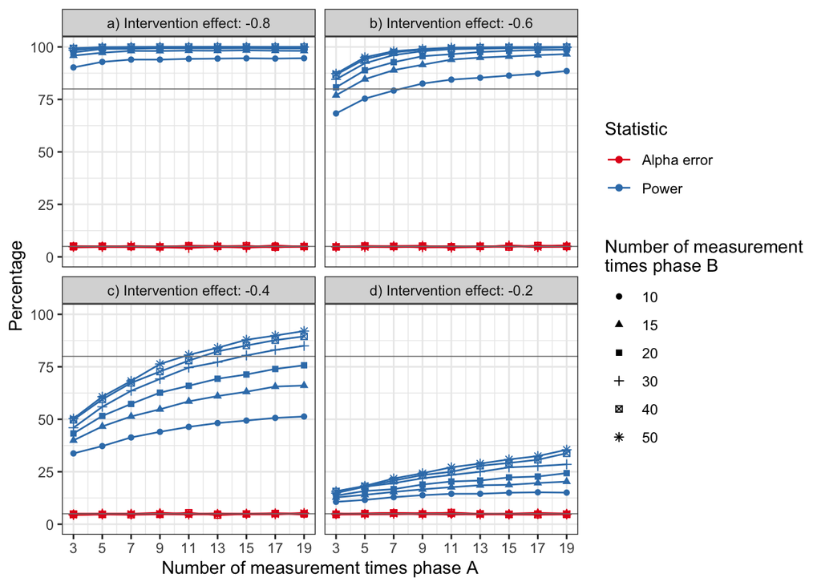

**Iterations:**  
A_length = c(3, 5, 7, 9, 11, 13, 15, 17, 19)  
B_length = c(10, 15, 20, 30, 40, 50)  
level_effect = c(-0.8, -0.6, -0.4, -0.2)  
n_sims = 10000  
**Design:**  
n = n_sims  
start_value = 15  
level = level_effect * 15  
trend = rnorm(n_sims, 0, abs(0.1 * 15/(A_length + B_length)))  
slope = rnorm(n_sims, 0, abs(0.1 * 15/B_length))  
phase_design = list(A = A_length, B = B_length)  
distribution = poisson

# Problemintensity, intervention effectiveness, and measurements

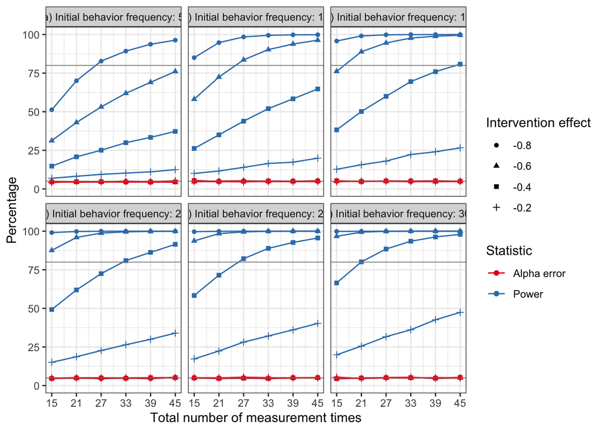

**Iterations:**  
problemintensity = c(5, 10, 15, 20, 25, 30)  
length = c(15, 21, 27, 33, 39, 45)  
level_effect = c(-0.2, -0.4, -0.6, -0.8)  
n_sims = 10000  
**Design:**  
n = n_sims  
start_value = problemintensity  
level = problemintensity * level_effect  
trend = rnorm(n_sims, 0, 0.1 * problemintensity/length)  
slope = rnorm(n_sims, 0, 0.1 * problemintensity/(length * 2/3))  
phase_design = list(A = length * 1/3, B = length * 2/3)  
distribution = poisson

# Strength of trend effect, problemintensity, and measurements

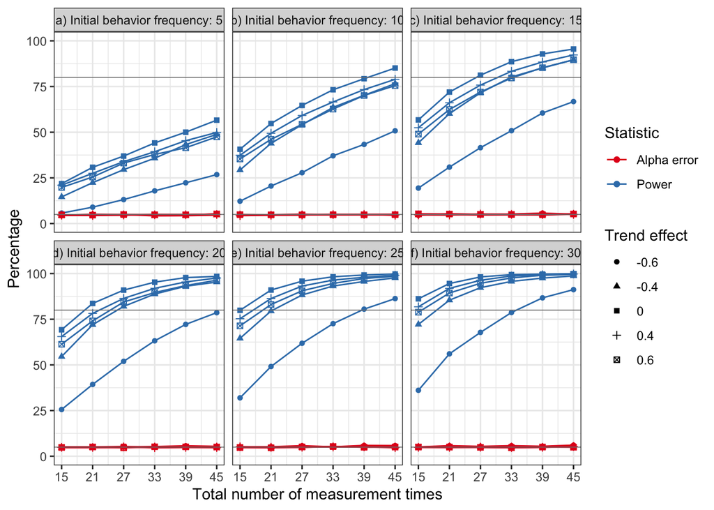

**Iterations:**  
problemintensity = c(5, 10, 15, 20, 25, 30)  
length = c(15, 21, 27, 33, 39, 45)  
trend_effect = c(-0.6, -0.4, 0, 0.4, 0.6)  
n_sims = 10000  
**Design:**  
n = n_sims  
start_value = problemintensity  
level = -(problemintensity * 0.5)  
trend = trend_effect * problemintensity/length  
slope = rnorm(n_sims, 0, abs(0.1 * problemintensity/(length * 2/3)))  
phase_design = list(A = length * 1/3, B = length * 2/3)  
distribution = poisson